Universidade Federal do Ceará Supervisão e Controle de Sistemas Elétricos de Potência # Atividade Complementar 3 # Lista de Exercícios 1 Supervisão e Controle de Sistemas Elétricos de Potência - 2024.2

Aluno: Yago Castro dos Reis; Matrícula: 494531.

Professor: Lucas Silveira Melo.

# 0.Imports

```python
from IPython.core.display import HTML
```

# Formatação da Página

```python
# Código de Cores ANSI
azul = "\033[38;2;10;31;68m"
verde = "\033[38;5;82m"
verde_escuro = "\033[38;2;0;100;0m"
laranja = "\033[38;5;208m"
reset = '\033[0m'

HTML('''
<style>
    /* Aplicar fonte monoespaçada a todo o notebook */
    body, div.text_cell_render, div.code_cell pre, h1, h2, h3, h4, p {
        font-family: "Courier New", Consolas, Monaco, monospace; /* Fonte monoespaçada */
    }

    /* Estilo para h1 */
    h3{
        color: #0a1f44;            /* Cor do texto (azul marinho) */
        background-color: #dcdde1; /* Fundo azul escuro (cinza mais escuro) */
        border-radius: 8px;        /* Bordas arredondadas */
        padding: 10px;
    }

    /* Estilo para h2 */
    h1{
        color: #dcdde1;            /* Cor do texto (cinza claro) */
        background-color: #0a1f44; /* Fundo azul escuro (azul marinho) */
        border-radius: 8px;        /* Bordas arredondadas */
        padding: 10px;
    }

    /* Estilo para h3 */
    h2{
        color:#dcdde1;            /* Cor do texto (azul mais claro) */
        background-color: #40739e; /* Fundo azul escuro (cinza mais escuro) */
        border-radius: 8px;        /* Bordas arredondadas */
        padding: 10px;
    }

    /* Estilo para h4 e h5 */
    h4, h5 {
        background-color:#40739e;  /* Fundo azul marinho */
        color: white;               /* Texto branco */
        border-radius: 8px;         /* Bordas arredondadas */
        padding: 10px;
    }
</style>
''')
```

# Lista de Exercícios sobre Fundamentos de Sistemas SCADA

## Questão 1

**Quais são os quatro níveis de automação relacionados à proteção e controle de subestações de energia elétrica, considerando a possibilidade de monitoramento remoto e integrado de um conjunto de subestações? Comente sobre cada um dos níveis.**

**Resposta:**

Os níveis trabalham de forma hierárquica e integrada, permitindo desde ações locais rápidas e automáticas até o monitoramento e gerenciamento estratégico em escala ampla.

### 0. Nível de Campo:

Responsável pela interação direta com os dispositivos primários e os sensores instalados na subestação. Ele inclui equipamentos como transformadores de corrente e potencial, sensores de temperatura, chaves seccionadoras e interruptores. - Função: Coletar dados diretamente dos ativos e realizar ações locais de controle (abertura e fechamento de disjuntores, por exemplo). - Conectividade: Interfaces locais para comunicação com níveis superiores.

### 1. Nível de Controle:

Realiza a supervisão e o controle local dos equipamentos da subestação. Ele é implementado por sistemas como CLPs (Controladores Lógicos Programáveis) ou IEDs (Dispositivos Eletrônicos Inteligentes), que agregam dados dos dispositivos de campo. - Função: Interpretar e processar informações recebidas do nível de campo, enviar comandos para equipamentos e registrar eventos. - Automação: Permite ações automáticas, como rearranjo da rede em caso de falhas, baseando-se em lógicas programadas. - Conectividade: Comunicação com o nível de supervisão para envio de dados e recebimento de comandos.

### 2. Nível de Supervisão:

Aqui está o SCADA, que realiza o monitoramento remoto em tempo real das operações de uma ou mais subestações. Função: Visualização, análise e controle da operação da subestação em um centro de controle. Automação: Suporte a decisões por meio de dados em tempo real e alarmes para operadores humanos. Conectividade: Comunicação com sistemas de controle local e sistemas corporativos (nível de gestão).

### 3. Nível de Gestão:

Neste nível, sistemas corporativos, como EMS (Energy Management Systems) ou DMS (Di stribution Management Systems),são utilizados para o gerenciamento integrado de um conjunto de subestações e da rede elétrica como um todo. Função: Analisar dados históricos e em tempo real para otimizar o desempenho, reduzir custos e melhorar a confiabilidade do sistema elétrico. Automação: Planejamento preditivo, análise de eficiência energética e resposta a eventos críticos em larga escala. Conectividade: Integração com sistemas SCADA, bancos de dados corporativos e redes inteligentes.

## Questão 2

**Com base na resposta do item anterior, descreva como a abertura de um disjuntor pode ser realizada em cada um dos níveis de automação de uma subestação. Descreva também como a atualização do estado do disjuntor é propagada em cada desses níveis via função de supervisão desse mesmo sistema.**

**Resposta:**

A abertura de um disjuntor em uma subestação pode ser realizada de maneiras diferentes em cada nível de automação, com base nos processos e nas funções específicas de cada nível.

### Disjuntor acionado a partir do nível 0 (Campo ou Processos)

1. Nível de Campo ou Processos Abertura do Disjuntor: No nível de campo, o disjuntor pode ser aberto automaticamente em resposta a uma falha detectada, como sobrecarga, curto-circuito ou outra anomalia. O relé de proteção responsável por monitorar o disjuntor detecta a falha e envia um comando para a abertura do disjuntor. Ou ele pode ser aberto de forma de manual no próprio painel do disjuntor.

O relé de proteção envia um sinal elétrico diretamente para o mecanismo de acionamento do disjuntor para abrir os contatos. A abertura é realizada de forma automática sem a intervenção de um operador, com base em condições predefinidas de proteção (tempo, corrente, etc.).

Propagação do Estado do Disjuntor: O estado do disjuntor (aberto ou fechado) é monitorado por sensores de posição (normalmente instalados no disjuntor). O estado é enviado diretamente para o IED (Dispositivo Eletrônico Inteligente) ou CLP, que registra a mudança de estado.

### Disjuntor acionado a partir do nível 1 (IED ou Controle)

1. Nível de Controle ou IDE

No nível de controle, o IED pode enviar um comando para abrir o disjuntor com base em uma análise local dos dados coletados dos sensores, ou em uma instrução do operador via sistema de controle local.

O IED ou CLP envia um sinal de controle para o mecanismo de acionamento do disjuntor para abrir os contatos. Em alguns casos, isso pode ser feito automaticamente com base em lógicas programadas (como a análise de falhas) ou manualmente, caso um operador queira abrir o disjuntor para manutenção ou outra razão. O estado do disjuntor (aberto ou fechado) é atualizado no IED, que transmite essa informação para o sistema SCADA (se disponível) e para o nível superior de supervisão.

### Disjuntor acionado a partir do nível 2 (Scada da Subestação ou Supervisão)

No nível de supervisão, o operador do SCADA pode acionar manualmente a abertura do disjuntor, ou o sistema SCADA pode automaticamente enviar um comando para abrir o disjuntor caso seja detectada uma condição crítica, como uma falha ou sobrecarga em outra parte da rede.

O SCADA envia um comando via comunicação de dados (geralmente através de protocolos como Modbus ou DNP3) para o IED, que então aciona o mecanismo de abertura do disjuntor. O SCADA pode ser configurado para tomar decisões automáticas baseadas em condições de falha, sem a intervenção manual do operador. Após o disjuntor ser aberto, o IED ou CLP envia a atualização do estado do disjuntor para o sistema SCADA.

### Disjuntor acionado a partir do nível 3 (Centro de Controle ou Gestão)

No nível de gestão, o EMS (Energy Management System) ou DMS (Distribution Management System) pode enviar um comando para abrir um disjuntor com base em uma análise estratégica ou operacional em larga escala da rede elétrica. Esse nível de gestão está mais focado na coordenação e no planejamento de longo prazo da rede, podendo agir sobre múltiplas subestações.

O sistema EMS ou DMS envia um comando para o sistema SCADA, que por sua vez repassa o comando para o IED. O IED então realiza a abertura do disjuntor.

## Questão 3

**Quais as tecnologias empregadas pelos relés de proteção desde sua concepção no início do século XX até os desenvolvimentos mais atuais? Descreva as principais características de cada uma.**

**Resposta:**

### Relés Eletromecânicos:

São baseados em componentes mecânicos, como bobinas e contatos. Funcionam por meio de um campo magnético gerado pela corrente elétrica que aciona os contatos para abrir ou fechar circuitos. São robustos, confiáveis e amplamente utilizados, mas possuem limitações em termos de velocidade e desgaste mecânico.

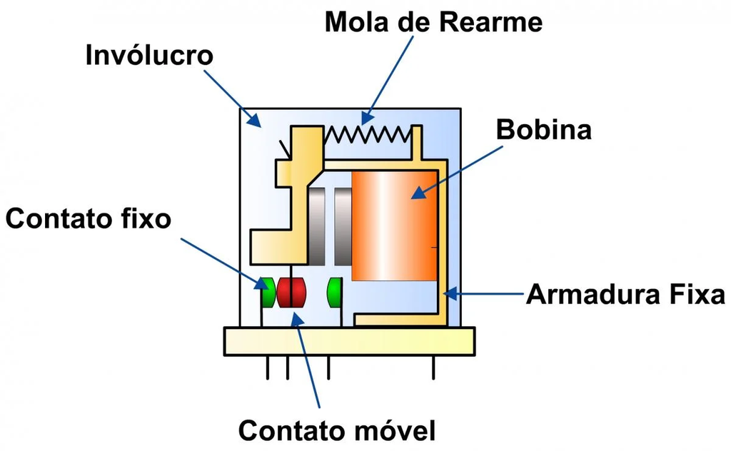

### Relés Eletrônicos:

Esses Utilizam componentes eletrônicos, como transistores e circuitos integrados, para realizar funções de proteção e controle. São mais rápidos, precisos e duráveis que os relés eletromecânicos, além de apresentarem menor consumo de energia. No entanto, podem ser mais sensíveis a interferências eletromagnéticas.

[figure not shown]

### Relés Numéricos:

São dispositivos microprocessados que utilizam algoritmos para monitorar e proteger sistemas elétricos. Possuem alta precisão, capacidade de comunicação digital e multifuncionalidade (podem executar várias funções de proteção simultaneamente). São amplamente usados em sistemas modernos devido à sua flexibilidade e capacidade de armazenamento de dados.

[figure not shown]

### Relés Virtuais:

São implementados por meio de software em sistemas, capaz de simular o comportamento de um relé físico sem a necessidade de um componente eletromecânico real.Não possuem hardware dedicado, sendo uma soluções flexíveis e modernas para a automação e proteção.

## Questão 04

**De quando data o primeiro protótipo de sistema de supervisão e controle de processos industriais? Descreva suscitamente os principais avanços até os dias de hoje.**

**Resposta:**

O primeiro protótipo de sistema de supervisão e controle de processos industriais data da década de 1940 , com o desenvolvimento dos controladores lógicos baseados em relés e painéis manuais.

Principais Avanços até os Dias de Hoje

- Década de 1960: Surgimento do CLP (Controlador Lógico Programável) Substituição de relés por dispositivos programáveis, permitindo maior flexibilidade e redução de espaço. Automatização mais eficiente de processos industriais.
- Década de 1970: Sistemas SCADA (Supervisory Control and Data Acquisition) Introdução de sistemas computacionais para monitorar e controlar processos remotamente. Coleta e análise de dados em tempo real.
- Década de 1980: Automação Digital e Redes Industriais Uso de microprocessadores e protocolos de comunicação (como Modbus). Integração entre dispositivos e sistemas.
- Década de 1990: Interfaces Gráficas e Sistemas Distribuídos Desenvolvimento de interfaces gráficas amigáveis (HMI - Human Machine Interface). SDCD (Sistemas Digitais de Controle Distribuído) para controle descentralizado.
- Anos 2000: Conectividade e Internet Industrial Incorporação de redes Ethernet e protocolos abertos. Início da integração com a internet e sistemas corporativos.
- Atualidade: Indústria 4.0 e IoT (Internet das Coisas) Uso de inteligência artificial, big data e machine learning para otimização de processos. Sistemas ciber-físicos, automação avançada e preditiva. Maior ênfase em segurança cibernética e interoperabilidade.

## Questão 05

**O que são as UTRs? Quais suas funcionalidades? Por que foram tão utilizadas na era dos relés eletromecânicos? Por que caíram em desuso? Em que situações ainda podem ser úteis? Qual sua principal diferença em relação aos modernos IEDs de proteção e controle?**

**Resposta:**

### O que são UTRs?

Uma UTR (Unidade Terminal Remota) é um dispositivo eletrônico que pode fazer parte dos sistemas de supervisão e controle, como os sistemas SCADA. Sua principal função é coletar dados de campo (como medições de sensores e status de equipamentos), executar comandos locais e comunicar essas informações remotamente com uma central de controle.

[figure not shown]

### Quais são as funcionalidades da UTR?

- Aquisição de Dados: Coleta de informações de sensores e dispositivos de campo (como temperatura, pressão, vazão, etc.). Esses dados são capturados para monitoramento, análise e tomada de decisões em sistemas de controle.
- Conversão de Sinais:Transformação dos sinais recebidos dos sensores (analógicos ou digitais) em um formato adequado para processamento pelo sistema de controle.
- Controle de Processos: Envolve a manipulação de variáveis de um sistema para garantir que ele opere conforme os parâmetros desejados.
- Lógica Programada: Implementação de regras e sequências lógicas pré-definidas em controladorespara automatizar decisões e ações no sistema.
- Comunicação: Envia e recebe informações para/desde a central de controle via protocolos de comunicação (ex.: Modbus, DNP3).

### Por que foram tão utilizadas na era dos relés eletromecânicos?

As Unidades Terminais Remotas (UTRs) eram amplamente utilizadas na era dos relés eletromecânicos porque permitiam a supervisão, controle e aquisição de dados (SCADA) em sistemas elétricos distribuídos. Como os relés eletromecânicos não possuíam comunicação digital integrada, as UTRs desempenhavam um papel essencial ao coletar sinais analógicos e digitais dos equipamentos de campo e transmiti-los para os centros de controle. Isso aumentava a eficiência da operação, possibilitava a automação e reduzia a necessidade de intervenção manual.

### Por que caíram em desuso?

As UTRs caíram em desuso devido à evolução dos relés digitais e sistemas de automação modernos, que passaram a integrar funções de proteção, controle e comunicação (IED), eliminando a necessidade de dispositivos intermediários. Além disso, protocolos de comunicação avançados, como IEC 61850, tornaram a troca de dados mais eficiente e segura, reduzindo a dependência das UTRs nos sistemas elétricos.

### Em que situações ainda podem ser úteis?

- Subestações antigas que não foram completamente modernizadas.
- Sistemas de distribuição de energia elétrica, para monitoramento e manobra de chaves remotas.
- Infraestruturas críticas, como oleodutos, gasodutos e redes ferroviárias, onde a automação e comunicação remota são essenciais.
- Ambientes industriais que precisam integrar sensores e atuadores dispersos a sistemas SCADA.

### Qual sua principal diferença em relação aos modernos IEDs de proteção e controle?

A principal diferença é que as UTRs apenas coletam, processam e transmitem dados, enquanto os IEDs (Intelligent Electronic Devices) possuem funções avançadas de proteção, controle e automação embutidas, eliminando a necessidade de dispositivos intermediários para a maioria das aplicações.

## Questão 06

**Comente suscitamente sobre os principais protolcolos de automação utilizados no ambiente de subestações. A saber modbus, DNP 3.0, IEC 101, IEC 104, MMS, GOOSE e Sampled Values**

**Resposta:**

### ModBus

Protocolo serial amplamente usado para comunicação entre dispositivos industriais. Suporta comunicação mestre-escravo e pode operar via RS-232, RS-485 e TCP/IP.

### DNP3:

Usado em sistemas SCADA para comunicação confiável em redes elétricas, suportando transmissão segura e eficiente de dados mesmo em condições adversas.

### IEC 60870-5-101 (IEC 101):

Protocolo serial para comunicação entre sistemas SCADA e equipamentos de subestações, adequado para redes de longa distância.

### IEC 60870-5-104 (IEC 104):

Variante do IEC 101 que utiliza TCP/IP para comunicação, permitindo integração com redes modernas.

### MMS (Manufacturing Message Specification):

Protocolo do padrão IEC 61850 usado para troca de dados estruturados entre dispositivos de automação de subestações, permitindo interoperabilidade entre diferentes fabricantes.

### GOOSE (Generic Object-Oriented Substation Event):

Protocolo IEC 61850 para transmissão rápida de eventos críticos entre dispositivos da subestação, reduzindo latências e melhorando a confiabilidade operacional.

### Sampled Values (SV):

Também do IEC 61850, permite a transmissão de amostras digitais de sinais analógicos, como corrente e tensão, entre dispositivos, garantindo medições sincronizadas e precisas.

## Questão 07

**Cite 5 exemplos de pontos digitais que devem ser monitorados pelo sistema SCADA de uma SE. Especifique o equipamento a que cada ponto está associado e contextualize sua funcionalidade.**

**Resposta:**

- Estado de Chave Seccionadora (Aberta/Fechada) Equipamento Associado: Chave Seccionadora. Funcionalidade: Indica a posição da chave seccionadora no barramento. Uma chave aberta garante o isolamento do circuito para manutenção ou proteção, enquanto uma chave fechada permite a continuidade do fornecimento de energia. Este monitoramento é crítico para evitar manobras incorretas, que podem comprometer a segurança e a operação da subestação.
- Estado de Disjuntor (Aberto/Fechado)

Equipamento Associado: Disjuntor de Potência. Funcionalidade: Informa se o disjuntor está em operação (fechado) ou isolando o circuito (aberto). Disjuntores protegem contra falhas elétricas, como sobrecorrentes ou curtos-circuitos, sendo essencial verificar se atuaram corretamente durante uma interrupção.

- Sinal de Proteção Ativa (Disparo de Relé de Proteção) Equipamento Associado: Relé de Proteção. Funcionalidade: Indica se o relé de proteção foi ativado devido a uma falha, como sobrecorrente ou perda de sincronismo. Esse sinal é utilizado para identificar rapidamente problemas no sistema, ajudando na resposta imediata para minimizar danos ao equipamento e ao sistema elétrico.
- Status do Transformador (Alarme de Temperatura) Equipamento Associado: Transformador de Potência. Funcionalidade: Detecta se a temperatura do óleo ou dos enrolamentos excedeu os limites de segurança. Um alarme digital pode ser acionado para alertar operadores sobre a necessidade de intervenção antes que ocorra uma falha no transformador, protegendo-o contra danos térmicos.
- Status do Sistema de Bancos de Capacitores (Ligado/Desligado) Equipamento Associado: Bancos de Capacitores. Funcionalidade: Indica se os bancos de capacitores estão em operação (ligados) ou desativados (desligados). O controle da compensação reativa é vital para manter o fator de potência da rede, melhorando a eficiência energética e evitando multas regulatórias.

## Questão 08

**Cite 5 exemplos de pontos analógicos que devem ser monitorados pelo sistema SCADA de uma SE. Especifique o equipamento a que cada ponto está associado e contextualize sua funcionalidade.**

**Resposta:**

- Tensão nas Barras (kV) Equipamento Associado: Transformador de Potencial (TP). Funcionalidade: Mede a tensão nas barras da subestação. O monitoramento contínuo permite identificar variações de tensão que podem indicar problemas na carga, no fornecimento de energia ou falhas no sistema de compensação reativa. Essa informação é essencial para garantir que os níveis de tensão estejam dentro dos limites normativos.
- Corrente de Linhas (A) Equipamento Associado: Transformador de Corrente (TC). Funcionalidade: Mede a corrente em cada circuito alimentador ou linha de transmissão. Monitorar a corrente ajuda a identificar sobrecargas ou possíveis falhas, como curtos-circuitos, antes que comprometam a estabilidade ou danifiquem os equipamentos da subestação.
- Potência Ativa e Reativa (kW e kVAR) Equipamento Associado: Medidores de Energia ou Relés de Proteção. Funcionalidade: Mede o fluxo de potência ativa e reativa em cada linha ou transformador. Esses dados são usados para analisar o desempenho da rede, calcular o fator de potência e otimizar o consumo de energia, garantindo o balanceamento adequado entre demanda e geração.
- Temperatura do Óleo do Transformador (°C) Equipamento Associado: Transformador de Potência. Funcionalidade: Monitora a temperatura do óleo de resfriamento do transformador. A temperatura elevada pode indicar sobrecarga, problemas de ventilação ou degradação do óleo isolante. O acompanhamento contínuo evita falhas catastróficas e prolonga a vida útil do equipamento.
- Pressão do Gás SF6 (kPa) Equipamento Associado: Disjuntor de Alta Tensão (com SF6). Funcionalidade: Mede a pressão do gás SF6 usado como isolante nos disjuntores de alta tensão. Uma pressão inadequada pode comprometer o desempenho do equipamento, aumentando o risco de falhas elétricas.

## Questão 09

**O que é uma Merge Unit? Para que serve? Por que vem sendo tão comentada nos últimos anos?**

**Resposta:**

Uma Merge Unit é um componente usado para consolidar múltiplos fluxos de dados em um único, sendo aplicada em redes, processadores e sistemas elétricos. Sua importância cresceu com o avanço das Smart Grids, da computação de alto desempenho e da IoT, otimizando a gestão de dados e o desempenho dos sistemas. No sistema elétrico, a Merge Unit unifica dados de sensores, permitindo monitoramento preciso, rápida detecção de falhas e otimização da proteção da rede, sendo essencial para Smart Grids.

## Questão 10

**Quais os principais protocolos especificados pela norma IEC 61850? Qual a funcionalidade de cada protocolo citado?**

**Resposta:**

IEC 61850 é um protocolo de padrão de comunicação internacional que atinge uniformidade de comunicação em toda a estação por meio de uma série de padronizações de funções de dispositivos. Amplamente usado na indústria de energia, o padrão IEC 61850 apresenta o conceito de camadas de informações na subestação, tanto do nível lógico quanto do físico. O sistema de automação da subestação é dividido em três níveis: o nível da estação, o nível da baía e o nível do processo. O ACSI é usado para trocar dados entre os níveis.

A IEC 61850 resume os serviços de comunicação necessários para a transmissão de informações dentro de uma subestação, projetando uma Interface de Serviço de Comunicação Abstrata (ACSI) que é independente dos protocolos de rede e camada de aplicação.

A implementação do serviço do padrão IEC 61850 é dividida em três partes: o serviço MMS, o serviço GOOSE e o serviço SV.

- O Serviço MMS é usado entre o Nível de Estação e o Nível de Baía do padrão IEC 61850. Ele alcança a interoperabilidade entre diferentes dispositivos de fabricação em um ambiente de rede usando uma abordagem de modelagem orientada a objetos dos dispositivos reais.
- O GOOSE (Generic Object Oriented Substation Event) é um mecanismo de mensagens rápidas na IEC 61850 para transmitir sinais importantes em tempo real entre IEDs em uma subestação.
- O SV (Valores Simplificados) é usado para Transmissão de Valores Amostrados no Nível de Processo, que é o serviço mais comumente usado para dados de medição em tempo real em subestações inteligentes.

Esses protocolos são projetados para garantir interoperabilidade, eficiência e confiabilidade em sistemas de automação de subestações. Eles permitem a integração de diferentes dispositivos e fabricantes, alinhando-se aos objetivos da norma IEC 61850 de padronizar a comunicação e melhorar a automação nos sistemas elétricos.

- MMS (Manufacturing Message Specification) Funcionalidade: Este é um padrão ISO (ISO 9506) usado para transferir dados de processo em tempo real e informações de controle de supervisão entre dispositivos em rede e/ou aplicativos de computador.

É o protocolo principal para comunicação cliente-servidor na IEC 61850. Usado para troca de informações entre dispositivos de automação e sistemas SCADA (Supervisory Control and Data Acquisition). Suporta a leitura e escrita de dados, execução de comandos e notificação de eventos. Aplicações:

Supervisão e controle de dispositivos. Transferência de informações como estados, medições e alarmes.

- GOOSE (Generic Object-Oriented Substation Event) Funcionalidade: Este é um mecanismo de modelo de controle na IEC 61850 que fornece um mecanismo rápido e confiável de transferência de dados orientados a eventos / dispositivos diretamente (peer-to-peer). Baseado em mensagens multicast no nível de enlace (Ethernet). Ideal para aplicações que exigem alta velocidade e baixa latência, como proteção e controle. Aplicações:

Proteção diferencial. Transferência de sinais de intertravamento. Ativação de dispositivos em resposta a eventos (ex.: disjuntores).

- SV (Sampled Values) Funcionalidade: Este protocolo é usado para transmitir representações digitalizadas de dados analógicos, como medições de corrente e tensão.

Transmissão de valores amostrados (correntes e tensões) de equipamentos como transformadores de corrente e tensão para dispositivos de proteção e medição. Utiliza multicast no nível de enlace (Ethernet). Aplicações:

Monitoramento e proteção em tempo real. Substituição de conexões físicas por comunicação digital em sistemas de proteção e medição.

- SMV (Sampled Measured Values) Funcionalidade:

Subconjunto do protocolo SV, focado em medições específicas. Permite a transmissão de dados de amostragem síncronos, como valores de tensão e corrente. Aplicações:

Medição sincronizada em sistemas de proteção. Sincronização de dados em sistemas de monitoramento.

- SNTP (Simple Network Time Protocol) Funcionalidade:

Sincronização de tempo entre dispositivos para garantir precisão e coordenação. Baseado no NTP, mas simplificado para atender requisitos de subestações. Aplicações:

Sincronização de relógios em equipamentos para registro de eventos e medições. Garantir consistência nos sistemas de proteção e controle.

- PRP/HSR (Parallel Redundancy Protocol/High-availability Seamless Redundancy) Funcionalidade:

Protocolo para alta disponibilidade de redes. Garante a comunicação sem interrupções por meio de redundância. PRP utiliza caminhos paralelos independentes, enquanto o HSR usa redes em anel. Aplicações:

Redes críticas em subestações que necessitam de alta confiabilidade e tolerância a falhas.

## Questão 11

**Qual a definição de Sistema SCADA (Supervisory Control and Data Acsition System)? Quais os principais elementos desse tipo de sistema? Comente sobre cada uma delas.**

**Resposta:**

SCADA (Supervisory Control and Data Acquisition) é um sistema utilizado para monitorar e controlar processos industriais, infraestruturas críticas e instalações em tempo real. Ele coleta dados de sensores e dispositivos espalhados por uma área geográfica ampla, processa esses dados e permite que operadores tomem decisões ou controlem remotamente os processos.

- UTRs (Unidades Terminais Remotas): Responsáveis por coletar dados diretamente dos sensores e atuadores no campo. Recebem sinais de equipamentos, como temperatura, pressão, fluxo, etc., e enviam essas informações para o sistema central.
- Sistema de Comunicação: Inclui redes de comunicação (cabos, rádio, fibra óptica, satélite, etc.) que conectam os dispositivos de campo ao sistema central. Garante a transmissão confiável dos dados coletados pelas UTRs até o servidor SCADA.
- Servidores SCADA: São computadores dedicados que processam os dados recebidos dos UTRs. Armazenam, processam e disponibilizam os dados para visualização e análise. Podem ser configurados para executar algoritmos de controle automático ou enviar alertas quando valores críticos são atingidos.
- Interface Homem-Máquina (HMI): É a interface gráfica utilizada pelos operadores para interagir com o sistema. presenta os dados coletados em formatos visuais (gráficos, tabelas, alarmes) e permite que os operadores controlem os processos remotamente.

## Questão 12

**Sobre os sinais analógicos, qual o padrão mais estabelecido para trasmissão desses sinais dos equipamentos de campo para os IEDs de proteção e controle? Especifique sua resposta em relação aos transformadores de instrumentos (TCs e TPs) e em relação às grandezas secundárias como temperatura, pressão, nível de líquidos, etc.**

**Resposta:**

-Transformadores de Corrente (TCs):

Saída típica: 5 A ou 1 A (corrente nominal secundária) . A escolha entre 5 A ou 1 A depende da distância entre o TC e o equipamento de proteção/controle (1 A é preferido para longas distâncias devido às menores perdas).

- Transformadores de Potencial (TPs): Saída típica: 115 V ou 100 V (tensão nominal secundária) . Esses valores são padronizados para medição e proteção, permitindo a conexão direta a relés e IEDs.

Esses padrões são amplamente adotados em normas internacionais, como as da IEC (International Electrotechnical Commission) e ANSI/IEEE

Grandezas Secundárias (Temperatura, Pressão, Nível, etc.):

- Padrões de Corrente: 4 a 20 mA : Este é o padrão mais estabelecido e amplamente utilizado para transmissão de sinais analógicos de sensores industriais. 4 mA representa o valor mínimo da faixa de medição (ex.: 0°C para temperatura). 20 mA representa o valor máximo da faixa de medição (ex.: 100°C para temperatura). A vantagem desse padrão é a capacidade de detectar falhas no circuito (ex.: 0 mA indica rompimento do cabo).
- Padrões de Tensão: 0 a 10 V ou 1 a 5 V : Embora menos comuns que o padrão de corrente, esses sinais de tensão também são utilizados em algumas aplicações industriais, especialmente quando a distância entre o sensor e o controlador é curta.

Esses padrões são regulamentados por normas como a IEC 60381 e NAMUR (associação de usuários de automação na indústria química).

## Questão 13

**Comente sobre cada um dos processos descritos na figura abaixo:**

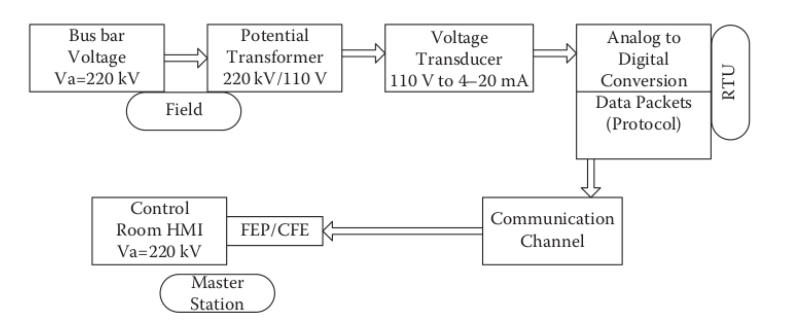

**Resposta:**

A imagem descreve um sistema típico do SCADA para monitoramento de tensão em sistemas elétricos.

- Bus Bar Voltage (Va = 220 kV): Representa a tensão da barra coletora (bus bar), que é de 220 kV. Essa é a tensão do sistema de potência que precisa ser monitorada.
- Potential Transformer (220 kV / 110 V): O transformador de potencial (TP) reduz a alta tensão de 220 kV para um nível seguro de 110 V, adequado para medições e processamento eletrônico.
- Voltage Transducer (110 V to 4–20 mA): O transdutor de tensão converte a tensão reduzida de 110 V em um sinal de corrente padronizado de 4–20 mA, usado para transmissão eficiente e menos suscetível a ruídos. É comum ser ligado direto sem transdutor de tensão.
- Analog to Digital Conversion (Data Packets - Protocol)[UTR]: O sinal analógico de 4–20 mA é convertido em um formato digital por uma Unidade Terminal Remota (UTR). A RTU processa os dados e os encapsula em pacotes de dados seguindo um protocolo de comunicação para envio ao sistema de controle.
- Communication Channel: Os dados digitalizados são transmitidos através de um canal de comunicação (pode ser fibra óptica, rádio, cabo ou outro meio), garantindo que as medições cheguem ao sistema central.
- Control Room HMI (Va = 220 kV): O sistema de Interface Homem-Máquina (HMI) na sala de controle recebe os dados da UTR e os apresenta de forma visual para operadores monitorarem a tensão da barra coletora.
- FEP/CFE (Master Station): O Front-End Processor (FEP) ou Control Front-End (CFE) gerencia a comunicação entre a UTR e o sistema mestre, garantindo que os dados sejam interpretados corretamente antes de serem exibidos no HMI.

## Questão 14

**Comente sobre a importância do sincronismo de tempo entre os disposisitivos de proteção e controle de uma subestação. Quais os principais protocolos utilizados para esse fim?**

**Resposta:**

O sincronismo de tempo entre dispositivos de proteção e controle em subestações é fundamental para garantir a coordenação eficaz, rápida e segura em caso de falhas. Isso assegura que os dispositivos atuem de forma sequencial, isolando rapidamente falhas e evitando danos aos equipamentos. A falta de sincronismo pode levar a falhas adicionais, danos e interrupções prolongadas no fornecimento de energia.

### Principais protocolos:

PTP (IEEE 1588): Protocolo de alta precisão, usado para sincronizar dispositivos com precisão de nanosegundos. NTP (Network Time Protocol): Usado para sincronização com precisão de milissegundos. GPS: Usado para fornecer uma referência de tempo precisa, especialmente em locais remotos. IEC 61850: Padrão de automação que pode utilizar PTP e NTP para sincronizar dispositivos em subestações.

O PTP (Precision Time Protocol - IEEE 1588) é o mais utilizado em subestações devido à sua alta precisão, capaz de sincronizar os dispositivos com precisão de nanosegundos. Isso é essencial para garantir que os relés de proteção e outros dispositivos de controle atuem de forma coordenada e eficiente em tempo real.

O NTP também é utilizado, principalmente em situações onde a precisão de milissegundos é suficiente, mas o PTP é preferido em sistemas críticos que exigem uma precisão muito maior. O GPS é frequentemente usado em conjunto com PTP ou NTP para fornecer uma fonte de tempo de referência externa precisa.

## Questão 15

**Quais as duas principais técnicas de coleta de dados entre os equipamentos supervisionados e os IEDs de proteção e controle? Mencione em sua resposta as vantagens e desvantagens de cada uma.**

**Resposta:**

- Comunicação via Protocolos Digitais (Ex.: IEC 61850, DNP3, Modbus) Essa técnica utiliza protocolos de comunicação padronizados para transferir dados entre os equipamentos de campo (como transformadores, disjuntores, etc.) e os IEDs. A comunicação pode ser feita por redes Ethernet ou seriais.

Vantagens:

- Velocidade e Eficiência: Permite a transmissão rápida de grandes volumes de dados em tempo real.
- Padronização: Facilita a interoperabilidade entre diferentes fabricantes de equipamentos.
- Flexibilidade: Suporta uma ampla gama de funções, como monitoramento, controle e diagnóstico remoto.
- Redução de Cabos: Substitui ligações físicas por redes digitais, reduzindo custos de cabeamento.

Desvantagens:

- Complexidade: Requer conhecimento técnico avançado para configuração e manutenção.
- Custo Inicial: Implementação de redes e dispositivos compatíveis pode ser cara.
- Dependência de Infraestrutura: Vulnerável a falhas na rede ou ataques cibernéticos.
- Coleta de Dados por Entradas/Saídas Analógicas e Digitais (Hardwired)

Nessa técnica, os sinais são transmitidos diretamente por meio de cabos físicos conectados aos IEDs. As entradas podem ser analógicas (ex.: corrente, tensão) ou digitais (ex.: estado de contatos).

Vantagens:

- Simplicidade: Fácil de implementar e entender, sem necessidade de protocolos complexos.
- Confiabilidade: Menos suscetível a falhas de rede ou interferências externas.
- Baixo Custo Inicial: Não requer infraestrutura de rede digital. Desvantagens:
- Limitação de Dados: Restrita à quantidade de cabos físicos instalados, limitando o número de pontos monitorados.
- Maior Custo de Manutenção: Grande quantidade de cabos pode dificultar a manutenção e aumentar o risco de falhas.
- Menor Flexibilidade: Difícil de expandir ou modificar sem adicionar novos cabos.

## Questão 16

**Comente sobre cada uma das funcionalidades de um IED de proteção e controle mostradas na figura abaixo:**

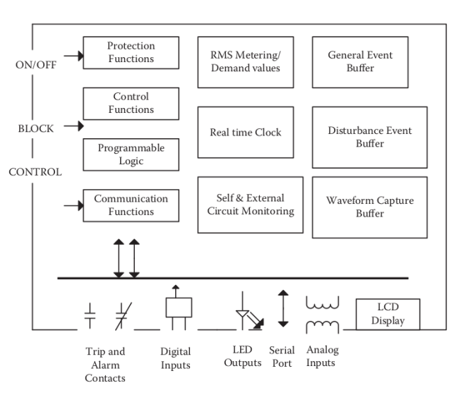

**Resposta:**

- Proteção: Detecta e atua contra falhas (sobrecorrente, sobretensão, etc.).
- Controle: Opera equipamentos elétricos local ou remotamente.
- Lógica Programável: Permite personalização de regras e ações.
- Comunicação: Integra-se a sistemas SCADA via protocolos como IEC 61850.
- Medição e Monitoramento: Mede grandezas elétricas e acompanha a demanda.
- Relógio de Tempo Real: Sincroniza eventos e facilita análises de falhas.
- Buffers de Eventos e Formas de Onda: Registram eventos operacionais e distúrbios para diagnóstico.

As interfaces incluem contatos de trip, entradas digitais, saídas de LED, porta serial, entradas analógicas e um display LCD, garantindo interação eficiente com o sistema elétrico.

# Lista de Exercícios sobre Protocolos de Rede de Camada de Enlace

## Questão 1

**Quais são alguns dos serviços possíveis que um protocolo da camada de enlace pode oferecer à camada de rede? Quais desses serviços da camada de enlace têm serviços correspondentes em IP? E em TCP?**

**Resposta:**

- Camada de enlace: Faz a transmissão de pacotes físicos e realiza controle de fluxo e detecção de erros.

### No IP (camada de rede):

A fragmentação é executada na camada de rede (IP), mas quando os pacotes chegam à camada de enlace, eles podem precisar ser transmitidos em partes menores dependendo das limitações da rede física (MTU - Maximum Transmission Unit). Por exemplo, se a camada de enlace tiver um MTU de 1500 bytes e o pacote IP tiver 5000 bytes, a camada de enlace precisará dividir esses pacotes ainda mais, em fragmentos adequados ao MTU.

Correspondência com serviços do TCP :

- Entrega confiável de quadros : TCP oferece entrega confiável de segmentos, com reconhecimento e retransmissão.
- Controle de fluxo : TCP implementa controle de fluxo usando janelas deslizantes.
- Detecção de erros : TCP usa checksums para detectar erros.
- Correção de erros : TCP corrige erros por meio de retransmissões.

## Questão 2

Suponha que dois nós comecem a transmitir ao mesmo tempo um pacote de comprimento L em um canal de transmissão de taxa R. Denote o atraso de propagação entre os dois nós como $d_{prop}$. Haverá uma colisão se $d_{prop} < L/R?$ Por que sim ou por que não?

**Resposta:**

- O comprimento do pacote, 𝐿 (em bits ou bytes).
- A taxa de transmissão 𝑅 (também chamada de largura de banda) do canal, que é a quantidade de dados transmitidos por unidade de tempo, geralmente medida em bits por segundo (bps).

A velocidade de propagação (prop) pode variar de acordo com o tipo de meio:

Cabo de cobre: cerca de 2/3 da velocidade da luz (∼200.000 km/s). Fibra óptica: próxima à velocidade da luz (∼300.000 km/s). Rádio (para comunicação sem fio): também próxima à velocidade da luz.

O tempo de propagação 𝑑 prop é dado por:

$$𝑑_{prop} = \frac{d}{v_{prop}}$$

Onde:

- 𝑑 é a distância entre os dois nós (em quilômetros ou metros).
- 𝑣 prop é a velocidade de propagação do sinal no meio de comunicação (em km/s ou m/s).
- Interação entre Transmissão e Propagação A transmissão de dados refere-se ao envio dos bits de um pacote de dados de um nó para outro, enquanto a propagação trata do tempo necessário para os sinais viajarem ao longo do canal. O tempo de transmissão depende do tamanho do pacote e da largura de banda do canal, enquanto o tempo de propagação depende da distância e da velocidade do sinal no meio de transmissão.

Observação:

- Especialmente importante em redes que usam CSMA/CD (Carrier Sense Multiple Access with Collision Detection), como Ethernet, onde os dispositivos precisam detectar colisões e retransmitir os pacotes se necessário.

## Questão 3

**Qual é o tamanho do espaço de endereços MAC? E do espaço de endereço IPv4? E do espaço de endereço IPv6?**

**Resposta:**

Espaço de endereços MAC: O endereço MAC (Media Access Control) é um identificador único atribuído a interfaces de rede para comunicação em uma rede local. O tamanho do espaço de endereços MAC é de 48 bits, ou seja, há 2^48 (281.474.976.710.656) endereços possíveis.

Espaço de endereço IPv4: O endereço IPv4 (Internet Protocol version 4) utiliza endereços de 32 bits, permitindo um total de 2^32 (4.294.967.296) endereços possíveis. Isso resulta em cerca de 4,3 bilhões de endereços.

Espaço de endereço IPv6: O endereço IPv6 (Internet Protocol version 6) usa endereços de 128 bits, o que permite 2^128 endereços possíveis, ou aproximadamente 3,4 x 10^38 endereços. Isso é uma quantidade enormemente maior que o espaço de endereços IPv4, atendendo à crescente demanda por endereços de IP em dispositivos conectados à internet.

## Questão 4

**Suponha que os nós A, B e C se conectem à mesma LAN de broadcast (por meio de seus adaptadores). Se A enviar milhares de datagramas IP para B com cada quadro de encapsulamento endereçado ao endereço MAC de B, o adaptador de C processará esses quadros? Se sim, o adaptador de C passará os datagramas IP nesses quadros para a camada de rede C? Como suas respostas mudariam se A enviasse quadros com o endereço MAC de broadcast?**

**Resposta:**

- Quadros com MAC de B : O adaptador de C recebe os quadros, mas os descarta porque o destino não é ele. Os datagramas IP não chegam à camada de rede de C.
- Quadros com MAC de broadcast : O adaptador de C processa os quadros e os passa para a camada de rede. Se o IP de destino for relevante para C, os datagramas são processados; caso contrário, são descartados.

## Questão 5

**Por que uma consulta ARP é enviada dentro de um quadro de broadcast? Por que uma resposta ARP é enviada dentro de um quadro com um endereço MAC de destino específico?**

**Resposta:**

A consulta ARP (Address Resolution Protocol) é enviada dentro de um quadro de broadcast porque, quando um dispositivo precisa descobrir o endereço MAC correspondente a um determinado endereço IP, ele ainda não sabe qual dispositivo na rede possui esse IP. Como resultado, a consulta ARP é enviada para todos os dispositivos na sub-rede (usando o endereço MAC de broadcast FF:FF:FF:FF:FF:FF), garantindo que o dispositivo correto receba a solicitação e possa responder.

Já a resposta ARP é enviada dentro de um quadro com um endereço MAC de destino específico porque, ao responder, o dispositivo que possui o endereço IP consultado já sabe para quem deve enviar a resposta. Ou seja, ele coloca o MAC do solicitante como destino no quadro Ethernet, garantindo que apenas o dispositivo que fez a solicitação receba a resposta.

- Se um computador com IP 192.168.1.10 quiser se comunicar com o IP 192.168.1.20, mas não souber seu endereço MAC, ele enviará uma consulta ARP com a seguinte mensagem:
- "Quem tem o IP 192.168.1.20? Responda com seu endereço MAC!"
- Se o dispositivo com 192.168.1.20 estiver na rede, ele responderá com seu endereço MAC, permitindo a comunicação.
- Isso permite que os dispositivos se comuniquem corretamente em redes Ethernet baseadas em IPv4.

## Questão 6

Compare as estruturas de quadro para as especificações Ethernet 10BASE-T, 100BASE-T e Gigabit Ethernet. Como elas diferem?

**Resposta:**

As principais diferenças entre essas tecnologias são:

- Velocidade: 10 Mbps (10BASE-T), 100 Mbps (100BASE-T) e 1 Gbps (1000BASE-T).
- Codificação: 10BASE-T usa Manchester, 100BASE-T usa 4B/5B + MLT-3 e 1000BASE-T usa 8B/10B ou 4D-PAM5, tornando a transmissão mais eficiente.
- Controle de Fluxo: 10BASE-T e 100BASE-T podem usar CSMA/CD, enquanto Gigabit Ethernet opera apenas em Full-Duplex sem colisões.
- Tamanho do Quadro: Todos mantêm 64-1518 bytes, mas 1000BASE-T pode suportar Jumbo Frames (até 9000 bytes) para maior eficiência.

## Questão 7

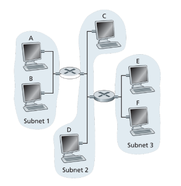

**Resposta:**

a. Atribua endereços IP a todas as interfaces. Para a Sub-rede 1, use endereços do formato 192.168.1.xxx; para a Sub-rede 2, use endereços do formato 192.168.2.xxx; e para a Sub-rede 3 use endereços do formato 192.168.3.xxx.

b. Atribua endereços MAC a todos os adaptadores.

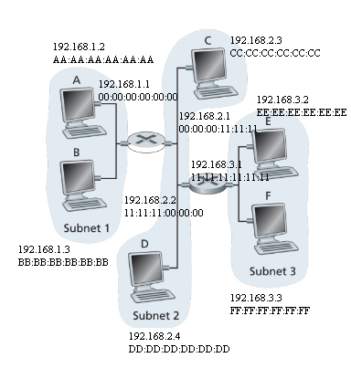

1. O Host E verifica se o IP de destino (192.168.1.3) está na mesma sub-rede (192.168.3.0/24). Como não está, o pacote deve ser enviado para o roteador 2 (192.168.3.1).

2.O Host E consulta sua tabela ARP e encontra o MAC do roteador (11:11:11:11:11:11).

3.O Host E encapsula o pacote IP com destino 192.168.1.3 em um quadro Ethernet com endereço MAC de destino 11:11:11:11:11:11 e envia para o roteador 2.

6.O roteador 1 encapsula o pacote IP em um quadro Ethernet com destino BB:BB:BB:BB:BB:BB e envia para o Host B.

7.O Host B recebe o quadro, desencapsula o pacote e processa os dados.

Caso a Tabela ARP do Host E Esteja Vazia (ITEM D)

1.O Host E precisa enviar o pacote para o roteador, mas não tem o endereço MAC de 192.168.3.1

2.O Host E envia um broadcast ARP (192.168.3.1?).

3.O roteador responde com seu endereço MAC (11:11:11:11:11:11).

4.O Host E armazena essa informação na tabela ARP e prossegue com os passos normais descritos na parte (c).

## Questão 8

**Qual a diferença entre hub, switch e roteador? Em quais situações a utilização de cada um é mais adequada?**

**Resposta:**

### Hub

É um dispositivo de rede que simplesmente **retransmite os dados para todas as máquinas conectadas a ele, sem qualquer tipo de filtragem**. Isso pode causar colisões de dados e reduzir a eficiência da rede.

### Switch

Ele filtra e direciona os dados apenas para o dispositivo correto, melhorando o desempenho da rede. **Ele analisa os pacotes de dados e usa os endereços MAC dos dispositivos para encaminhar os dados diretamente para o destino correto** Reduz colisões e melhora a eficiência da rede.

### Roteador

**Conecta redes diferentes e é essencial para a comunicação entre dispositivos dentro e fora de uma rede local**

- Gerencia IPs, permite Wi-fi. Acesso à internet e redes interligadas.

## Questão 9

**Explique qual tipo de problema as VLANs podem resolver e especifique, em termos de hardware, os requisitos necessários para sua implementação.**

**Resposta:**

As VLANs são uma solução essencial para redes modernas, resolvendo problemas de segmentação, segurança, desempenho e escalabilidade. Para implementá-las, é necessário um switch gerenciável com suporte a VLANs e, dependendo da necessidade de comunicação entre VLANs, um switch de camada 3 ou um roteador com suporte a VLAN tagging. Essa tecnologia é amplamente utilizada em redes corporativas, data centers e ambientes onde há necessidade de segmentação lógica sem alterar a infraestrutura física.

## Questão 10

**O que são as portas trunk dos switchs nível 3?**

**Resposta:**

As portas trunk em switches de nível 3 (camada 3 do modelo OSI) são portas configuradas para transportar tráfego de múltiplas VLANs ao mesmo tempo, utilizando um processo chamado VLAN tagging (ou marcação de VLANs), geralmente com o protocolo IEEE 802.1Q.

- Utilizamos apenas um cabo de rede entre os switches, e ele transporta todas as VLANs.
- O protocolo 802.1Q adiciona um identificador de VLAN a cada pacote para que o switch receptor saiba a qual VLAN cada pacote pertence.